# You_lab3

Angelina You

2/7/2019

### Report Question

As part of your report for this lab, answer the following question: What is a “suspicious multiple”? Provide two concrete examples and explain why we should be on the watch for such values.

**Answer: a “suspicious multiple” is the value that may be inaccurate or does not logically make sense. More specifically, the tutorial talks about the suspicious multiple due to rounding. For instance, if we have “age” variable that is over 150 or negative that can be seen as impossible and suspicious. Another example can be the population data from the US Census. Since it may be counted in million, we might lose the precision using such data.**

### Exercises

#### 5.5.2

1. Currently dep_time and sched_dep_time are convenient to look at, but hard to compute with because they’re not really continuous numbers. Convert them to a more convenient representation of number of minutes since midnight. Then, compare the difference between these new variables to each flight’s dep_delay value. Does anything surprise you? Can you explain what accounts for the “anomaly”? How many cases do you observe?

Include as part of your report a listing that shows the first five observations of a tibble with the following columns: carrier, flight, your two new variables, their difference, and dep_delay.

**Answer: I create a function called to_mins to convert the time to minutes. Comparing the difference between the new variable, dep_delay_mins and each flight’s dep_delay value, I surprisingly found that for 1207 rows in the dataset, the de_delay value is not equal to the new variable, dep_delay_mins. After examing the data, I realized that because the converting function does not consider the case when depature time is one day later than the scheduled depature time, our new variable is inaccurate in such corner cases and generates such anomaly. It happens a lot, when the scheduled depature time is around midmight. For example, for the flight B6 707 that scheduled depature time at 23:59 but departed at 0:42, the correct delay time is 43 minutes but the new variable returns -1397.**

```r
library(nycflights13)
library(tidyverse)
#
to_mins <- function(x) {
  x %/% 100 * 60 + x %% 100
}
# with integer division
new_measure <-mutate( flights,
       dep_time_mins = to_mins(dep_time),
       sched_dep_time_mins = to_mins(sched_dep_time),
       dep_delay_mins = to_mins(dep_time) - to_mins(sched_dep_time),
       dep_diff = dep_delay - dep_delay_mins
)
filter(new_measure, dep_diff != 0)
```

```
## # A tibble: 1,207 x 23
##     year month   day dep_time sched_dep_time dep_delay arr_time
##    <int> <int> <int>    <int>          <int>     <dbl>    <int>
##  1  2013     1     1      848           1835       853     1001
##  2  2013     1     2       42           2359        43      518
##  3  2013     1     2      126           2250       156      233
##  4  2013     1     3       32           2359        33      504
##  5  2013     1     3       50           2145       185      203
##  6  2013     1     3      235           2359       156      700
##  7  2013     1     4       25           2359        26      505
##  8  2013     1     4      106           2245       141      201
##  9  2013     1     5       14           2359        15      503
## 10  2013     1     5       37           2230       127      341
## # ... with 1,197 more rows, and 16 more variables: sched_arr_time <int>,
## #   arr_delay <dbl>, carrier <chr>, flight <int>, tailnum <chr>,
## #   origin <chr>, dest <chr>, air_time <dbl>, distance <dbl>, hour <dbl>,
## #   minute <dbl>, time_hour <dttm>, dep_time_mins <dbl>,
## #   sched_dep_time_mins <dbl>, dep_delay_mins <dbl>, dep_diff <dbl>
```

### 5.6.7

4. Is the proportion of canceled flights per day related to the average delay for that day? Output a csv file that will allow you to make a scatter plot of the proportion of cancelled flights vs. the average delay for that day.

**Answer: From our analysis, we can see that the correlation between proportion of canceled flights per day and the average delay for that day is 0.574, which means there is moderately positive relationship between these two variables. From the plot, we can also see the positive linear relationship between these two variables.**

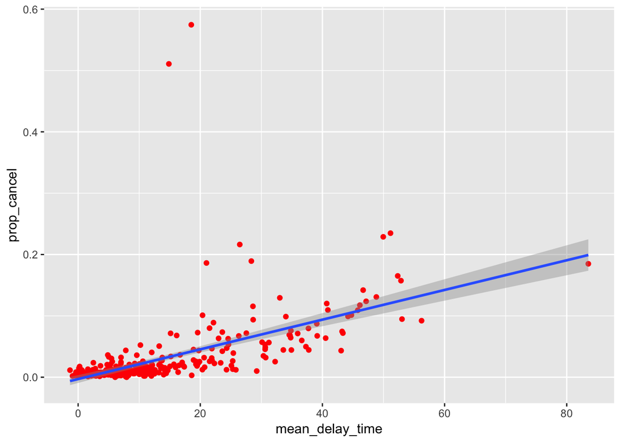

```r
# Create a new dataset
cancel<-group_by(flights,year, month,day) %>%
   summarise(
     n=n(),
     canceled= sum(is.na(dep_delay)|is.na(arr_delay)),
     prop_cancel = canceled/n,
     mean_delay_time = mean(dep_delay, na.rm = TRUE))

# Export to the csv file
write.csv(cancel, file ="cancel and delay.csv")

# How the proportion of canceled fights per day related to the average delay for that day
ggplot(cancel,aes(y=prop_cancel,x=mean_delay_time))+
  geom_point(colour = "red")+
  geom_smooth(method=lm)
```

```r
cor(cancel$prop_cancel,cancel$mean_delay_time)
```

```
## [1] 0.5740459
```

To complete exercise 5.6.7-5 you will need to run the code that appears earlier in the tutorial in order to create the not_cancelled tibble.

5. Which carrier, on average, has the shortest departure delays? In your response, provide the name of the airline, not simply two-letter carrier code. Contextualize this delay with respect to delays of other airlines.

```r
not_cancelled <- group_by(flights, carrier) %>%
  filter(!is.na(dep_delay), !is.na(arr_delay)) %>%
  summarise(mean_dep_delay = mean(dep_delay, na.rm = TRUE)) %>%
  arrange(mean_dep_delay)
mean(not_cancelled$mean_dep_delay)
```

```
## [1] 12.793
```

```r
not_cancelled
```

```
## # A tibble: 16 x 2
##    carrier mean_dep_delay
##    <chr>            <dbl>
##  1 US                3.74
##  2 HA                4.90
##  3 AS                5.83
##  4 AA                8.57
##  5 DL                9.22
##  6 MQ               10.4
##  7 UA               12.0
##  8 OO               12.6
##  9 VX               12.8
## 10 B6               13.0
## 11 9E               16.4
## 12 WN               17.7
## 13 FL               18.6
## 14 YV               18.9
## 15 EV               19.8
## 16 F9               20.2
```